# Ecommerce Fraud Data

```python
import numpy as np
import pandas as pd
import matplotlib.pyplot as plt
import seaborn as sns
import re
from sklearn.model_selection import train_test_split
from sklearn.preprocessing import StandardScaler
from sklearn.model_selection import StratifiedKFold, RepeatedStratifiedKFold
import tldextract
from sklearn.metrics import precision_recall_curve, auc, average_precision_score, precision_score, recall_score, accuracy_score, f1_score, roc_auc_score
from sklearn.pipeline import Pipeline
from sklearn.model_selection import cross_val_predict, cross_validate, cross_val_score
from sklearn.linear_model import LogisticRegression
from sklearn.tree import DecisionTreeClassifier
from sklearn.ensemble import RandomForestClassifier, GradientBoostingClassifier, HistGradientBoostingClassifier
from xgboost import XGBClassifier
from lightgbm import LGBMClassifier
from catboost import CatBoostClassifier
import ipaddress
import category_encoders as ce
from scipy.stats import uniform, randint
from sklearn.model_selection import RandomizedSearchCV
from sklearn.base import clone
from sklearn.base import BaseEstimator, TransformerMixin
from sklearn.compose import ColumnTransformer
import optuna
```

```python
trans = pd.read_csv('./cust_transaction_details (1).csv')
customer = pd.read_csv('./Customer_DF (1).csv')
```

```python
trans
```

|  | Unnamed: 0 | customerEmail | transactionId | orderId | paymentMethodId | paymentMethodRegistrationFailure | paymentMethodType | paymentMethodProvider | transactionAmount | transactionFailed | orderState |
| --- | --- | --- | --- | --- | --- | --- | --- | --- | --- | --- | --- |
| 0 | 0 | josephhoward@yahoo.com | a9lcj51r | vjbdvd | wt07xm68b | 1 | card | JCB 16 digit | 18 | 0 | pending |
| 1 | 1 | josephhoward@yahoo.com | y4wcv03i | yp6x27 | wt07xm68b | 1 | card | JCB 16 digit | 26 | 0 | fulfilled |
| 2 | 2 | evansjeffery@yahoo.com | 5mi94sfw | nlghpa | 41ug157xz | 0 | bitcoin | American Express | 45 | 0 | fulfilled |
| 3 | 3 | evansjeffery@yahoo.com | br8ba1nu | uw0eeb | 41ug157xz | 0 | bitcoin | American Express | 23 | 0 | fulfilled |
| 4 | 4 | evansjeffery@yahoo.com | a33145ss | bn44oh | y3xp697jx | 1 | bitcoin | VISA 16 digit | 43 | 1 | fulfilled |
| ... | ... | ... | ... | ... | ... | ... | ... | ... | ... | ... | ... |
| 618 | 618 | dawn05@tucker-brown.com | 7yilsi1o | 1bubxa | 7yen1m1q8 | 0 | card | VISA 13 digit | 25 | 1 | fulfilled |
| 619 | 619 | dawn05@tucker-brown.com | c82k5bcv | 1bubxa | 7yen1m1q8 | 0 | card | VISA 13 digit | 25 | 0 | fulfilled |
| 620 | 620 | dawn05@tucker-brown.com | wmh52bns | 1bubxa | 3zmkegkb8 | 0 | paypal | JCB 15 digit | 25 | 1 | fulfilled |
| 621 | 621 | dawn05@tucker-brown.com | xdw33hfp | p0gdbf | 3zmkegkb8 | 0 | paypal | JCB 15 digit | 19 | 0 | fulfilled |
| 622 | 622 | dawn05@tucker-brown.com | wgmajf82 | 5lmvrj | f0xnu5om9 | 0 | card | JCB 16 digit | 27 | 0 | fulfilled |

623 rows × 11 columns

```python
customer
```

|  | Unnamed: 0 | customerEmail | customerPhone | customerDevice | customerIPAddress | customerBillingAddress | No_Transactions | No_Orders | No_Payments | Fraud |
| --- | --- | --- | --- | --- | --- | --- | --- | --- | --- | --- |
| 0 | 0 | josephhoward@yahoo.com | 400-108-5415 | yyeiaxpltf82440jnb3v | 8.129.104.40 | 5493 Jones Islands\nBrownside, CA 51896 | 2 | 2 | 1 | False |
| 1 | 1 | evansjeffery@yahoo.com | 1-788-091-7546 | r0jpm7xaeqqa3kr6mzum | 219.173.211.202 | 356 Elizabeth Inlet Suite 120\nPort Joshuabury... | 3 | 3 | 7 | True |
| 2 | 2 | andersonwilliam@yahoo.com | 024.420.0375 | 4m7h5ipl1shyavt6vv2r | 67b7:3db8:67e0:3bea:b9d0:90c1:2b60:b9f0 | 8478 Sean Ridges Apt. 441\nDavisberg, PR 72250 | 5 | 3 | 2 | False |
| 3 | 3 | rubenjuarez@yahoo.com | 670.664.8168x94985 | slovx60t0i558may4ks0 | 95de:8565:5a66:792c:26e0:6cfb:7d87:11af | 7769 Elizabeth Bridge Apt. 343\nNortonstad, FM... | 3 | 3 | 1 | False |
| 4 | 4 | uchen@malone.com | 1-981-877-0870 | j0pd24k5h8dl2fqu0cz4 | 196.89.235.192 | 148 Russell Lodge Apt. 445\nPort Jenniferside,... | 7 | 7 | 6 | True |
| ... | ... | ... | ... | ... | ... | ... | ... | ... | ... | ... |
| 163 | 163 | mitchellvickie@brewer-jones.com | 313-124-3836x3528 | ecu7ezz0ue67v3fce1o3 | 181.90.104.120 | 829 Ramirez Dam Suite 648\nGatesview, OR 55669... | 3 | 3 | 1 | True |
| 164 | 164 | sbrown@hughes.biz | (250)632-6631x02499 | xgv918sclaz40qlp2fee | 16.166.2.0 | 9472 Pacheco Islands Suite 940\nDrewburgh, AZ ... | 6 | 5 | 3 | True |
| 165 | 165 | johnlowery@gmail.com | 635.676.0955x524 | 969zz9zdj8z4gns4sx5p | f82c:811f:8a02:e2d6:79b:fcaa:42de:570b | 548 Bryant Inlet\nVeronicaside, OK 00522 | 4 | 4 | 2 | True |
| 166 | 166 | ethompson@jackson-sanders.com | 962.300.2250 | navessqcnmc9csfjn5cj | 203.246.172.244 | 16953 Jennifer Springs\nKathybury, IL 02095-3215 | 8 | 6 | 6 | True |
| 167 | 167 | dawn05@tucker-brown.com | (089)703-7360x8848 | lu4fgcug8dr0dwbcuui1 | 132.132.95.33 | 130 Kimberly Junctions\nEricmouth, KS 59756-2919 | 7 | 5 | 4 | False |

168 rows × 10 columns

```python
print(trans.columns.intersection(customer.columns))
```

```
Index(['Unnamed: 0', 'customerEmail'], dtype='object')
```

trans表有623行，customer表有168行。两张表中只有Unnamed: 0和customerEmail可以作为连接键。其中Unnamed: 0只是索引故考虑排除。 先查看customer表中的customerEmail是否都唯一。

```python
customer['customerEmail'].value_counts().sort_values(ascending=False)
```

```
customerEmail
johnlowery@gmail.com               8
josephhoward@yahoo.com             1
evansjeffery@yahoo.com             1
rubenjuarez@yahoo.com              1
andersonwilliam@yahoo.com          1
                                  ..
patrickcalderon@russo.net          1
mitchellvickie@brewer-jones.com    1
sbrown@hughes.biz                  1
ethompson@jackson-sanders.com      1
dawn05@tucker-brown.com            1
Name: count, Length: 161, dtype: int64
```

```python
customer[customer['customerEmail']=='johnlowery@gmail.com']
```

|  | Unnamed: 0 | customerEmail | customerPhone | customerDevice | customerIPAddress | customerBillingAddress | No_Transactions | No_Orders | No_Payments | Fraud |
| --- | --- | --- | --- | --- | --- | --- | --- | --- | --- | --- |
| 7 | 7 | johnlowery@gmail.com | 044-642-9860 | rjb0adai34izqvys4938 | 212.144.68.190 | 484 Pamela Pass\nLake Jessicaview, WI 12942-9074 | 6 | 5 | 2 | True |
| 40 | 40 | johnlowery@gmail.com | 737-377-9701x577 | jz66ap43id2y35ivfqa5 | 6c21:ac1d:2089:68fa:abb7:8c00:525f:6588 | 08238 Kyle Squares Suite 893\nMillermouth, IN ... | 0 | 0 | 1 | True |
| 45 | 45 | johnlowery@gmail.com | +16(4)9016414340 | cdx178qymd6vy77nm4x3 | 222.79.159.140 | 77711 Pamela Ridge\nNew Kayla, IL 27182 | 3 | 2 | 1 | True |
| 65 | 65 | johnlowery@gmail.com | 04712252182 | 311kdz4c1210iixltk2j | 42b3:df19:86fe:abd9:dafe:f6c1:eb76:c72 | 11704 Andrew Villages Apt. 035\nJamesfurt, OR ... | 7 | 5 | 1 | True |
| 79 | 79 | johnlowery@gmail.com | 1-820-539-4726x993 | 2in0fh7lep289n8dcbdz | 163.128.139.42 | 814 Wagner Union\nAshleymouth, HI 35617 | 2 | 2 | 1 | True |
| 133 | 133 | johnlowery@gmail.com | 1-143-059-1833 | tyijaify2hqadwslejyr | e4c:fb48:8ee2:9819:6ae8:8d3f:3b6a:a788 | 518 Wood Mews Apt. 970\nDillonstad, NE 43317-3945 | 0 | 0 | 0 | True |
| 155 | 155 | johnlowery@gmail.com | 076-099-0630x72770 | 6qy6oa3nqutsyyxzc54c | f259:657f:f329:2fca:c06c:8b57:d6ac:2380 | 687 Rogers Bridge Suite 780\nValdezburgh, IN 2... | 6 | 5 | 3 | True |
| 165 | 165 | johnlowery@gmail.com | 635.676.0955x524 | 969zz9zdj8z4gns4sx5p | f82c:811f:8a02:e2d6:79b:fcaa:42de:570b | 548 Bryant Inlet\nVeronicaside, OK 00522 | 4 | 4 | 2 | True |

因为该邮箱（johnlowery@gmail.com）有多个ip，设备，手机，且都为诈骗。 考虑到如果简单的随机保留一行该邮箱的数据可能会造成数据污染，因此因此需先处理cutomer表后再合并。

```python
display(customer.info())
display(customer.nunique().sort_values(ascending=False))
```

```
<class 'pandas.core.frame.DataFrame'>
RangeIndex: 168 entries, 0 to 167
Data columns (total 10 columns):
 #   Column                  Non-Null Count  Dtype
---  ------                  --------------  -----
 0   Unnamed: 0              168 non-null    int64
 1   customerEmail           168 non-null    object
 2   customerPhone           168 non-null    object
 3   customerDevice          168 non-null    object
 4   customerIPAddress       168 non-null    object
 5   customerBillingAddress  168 non-null    object
 6   No_Transactions         168 non-null    int64
 7   No_Orders               168 non-null    int64
 8   No_Payments             168 non-null    int64
 9   Fraud                   168 non-null    bool
dtypes: bool(1), int64(4), object(5)
memory usage: 12.1+ KB
```

```
None
```

```
Unnamed: 0                168
customerPhone             168
customerDevice            168
customerBillingAddress    166
customerIPAddress         165
customerEmail             161
No_Transactions            13
No_Payments                11
No_Orders                   9
Fraud                       2
dtype: int64
```

**特征工程**：

```python
def extract_address_features(df, address_col, zip_type='int'):
    s = df[address_col]

    # 提取邮编
    df['addr_zipcode'] = s.str.extract(r'\b(\d{5})(?:-\d{4})?\b')[0]
    # 截取前两位前缀
    df['zipcode_prefix'] = df['addr_zipcode'].astype(str).str[:2].astype(zip_type)
    # 军邮标记
    df['addr_is_military'] = s.str.contains(r'\b(?:APO|FPO|DPO|AE|AA|AP)\b',
                                            case=False, na=False, regex=True).astype(int)
    return df
```

```python
# 检查ip是否为私人
def ip_is_private(series):
    def check(ip):
        try:
            address = ipaddress.ip_address(ip)
            return int(address.is_private or address.is_loopback or address.is_link_local)
        except ValueError:
            return np.nan
    return series.fillna('').apply(check)
```

```python
# 提取邮箱域名和后缀
import tldextract
def email_domain(series):
    def extract(email):
        try:
            email = tldextract.extract(email)
            return 'missing' if email.domain == '' else email.domain
        except:
            return None
    return series.apply(extract)
def email_suffix(series):
    def extract(email):
        try:
            email = tldextract.extract(email)
            return 'missing' if email.suffix == '' else email.suffix
        except:
            return None
    return series.apply(extract)
# 检查邮箱是否为免费邮箱
def email_is_free(df, email_domail_col):
    free_email = {
        "gmail","yahoo","outlook","hotmail","live","icloud",
        "qq","163","126","sina","yeah","mail","protonmail","aol","zoho","gmx","yandex"
    }
    df['email_is_free'] = df[email_domail_col].isin(free_email).astype(int)
    return df
```

```python
customer = extract_address_features(customer, 'customerBillingAddress', zip_type='str') # drop addr_zipcode, customerBillingAddress
customer['ip_is_private'] = ip_is_private(customer['customerIPAddress']) # drop customerIPAddress
customer['email_domain'] = email_domain(customer['customerEmail'])
customer['email_suffix'] = email_suffix(customer['customerEmail'])
customer = email_is_free(customer, 'email_domain')
customer = customer.drop(['customerPhone','customerDevice', 'addr_zipcode', 'zipcode_prefix','email_domain', 'customerBillingAddress', 'customerIPAddress'], axis=1)
```

针对出现了多次的Email：

```python
customer[customer.select_dtypes(include=['object']).groupby('customerEmail').transform('nunique') > 1] = 'multiple'

cols = ['No_Transactions', 'No_Orders', 'No_Payments', 'zipcode_counts']
```

```python
# 合并
customer = customer.drop_duplicates(subset=['customerEmail'], keep='first')
trans.drop('Unnamed: 0', axis=1, inplace=True)
customer.drop('Unnamed: 0', axis=1, inplace=True)
data = pd.merge(trans, customer, on='customerEmail', how='inner')
data = data.drop('customerEmail', axis=1)
data
```

|  | transactionId | orderId | paymentMethodId | paymentMethodRegistrationFailure | paymentMethodType | paymentMethodProvider | transactionAmount | transactionFailed | orderState | No_Transactions | No_Orders | No_Payments | Fraud | addr_is_military | ip_is_private | email_suffix | email_is_free |
| --- | --- | --- | --- | --- | --- | --- | --- | --- | --- | --- | --- | --- | --- | --- | --- | --- | --- |
| 0 | a9lcj51r | vjbdvd | wt07xm68b | 1 | card | JCB 16 digit | 18 | 0 | pending | 2 | 2 | 1 | False | 0 | 0 | com | 1 |
| 1 | y4wcv03i | yp6x27 | wt07xm68b | 1 | card | JCB 16 digit | 26 | 0 | fulfilled | 2 | 2 | 1 | False | 0 | 0 | com | 1 |
| 2 | 5mi94sfw | nlghpa | 41ug157xz | 0 | bitcoin | American Express | 45 | 0 | fulfilled | 3 | 3 | 7 | True | 0 | 0 | com | 1 |
| 3 | br8ba1nu | uw0eeb | 41ug157xz | 0 | bitcoin | American Express | 23 | 0 | fulfilled | 3 | 3 | 7 | True | 0 | 0 | com | 1 |
| 4 | a33145ss | bn44oh | y3xp697jx | 1 | bitcoin | VISA 16 digit | 43 | 1 | fulfilled | 3 | 3 | 7 | True | 0 | 0 | com | 1 |
| ... | ... | ... | ... | ... | ... | ... | ... | ... | ... | ... | ... | ... | ... | ... | ... | ... | ... |
| 618 | 7yilsi1o | 1bubxa | 7yen1m1q8 | 0 | card | VISA 13 digit | 25 | 1 | fulfilled | 7 | 5 | 4 | False | 0 | 0 | com | 0 |
| 619 | c82k5bcv | 1bubxa | 7yen1m1q8 | 0 | card | VISA 13 digit | 25 | 0 | fulfilled | 7 | 5 | 4 | False | 0 | 0 | com | 0 |
| 620 | wmh52bns | 1bubxa | 3zmkegkb8 | 0 | paypal | JCB 15 digit | 25 | 1 | fulfilled | 7 | 5 | 4 | False | 0 | 0 | com | 0 |
| 621 | xdw33hfp | p0gdbf | 3zmkegkb8 | 0 | paypal | JCB 15 digit | 19 | 0 | fulfilled | 7 | 5 | 4 | False | 0 | 0 | com | 0 |
| 622 | wgmajf82 | 5lmvrj | f0xnu5om9 | 0 | card | JCB 16 digit | 27 | 0 | fulfilled | 7 | 5 | 4 | False | 0 | 0 | com | 0 |

623 rows × 17 columns

`transactionId` 为索引，因此不用做特征。  
同时把数据分成8:2的训练集和测试集，并进行数据清洗和特征工程：

```python
data.drop('transactionId', axis=1, inplace=True)
```

```python
train, test = train_test_split(data, test_size=0.2, random_state=42)
```

```python
display(train.isnull().sum())
display(train.nunique().sort_values(ascending=False))
```

```
orderId                             0
paymentMethodId                     0
paymentMethodRegistrationFailure    0
paymentMethodType                   0
paymentMethodProvider               0
transactionAmount                   0
transactionFailed                   0
orderState                          0
No_Transactions                     0
No_Orders                           0
No_Payments                         0
Fraud                               0
addr_is_military                    0
ip_is_private                       0
email_suffix                        0
email_is_free                       0
dtype: int64
```

```
orderId                             405
paymentMethodId                     223
transactionAmount                    67
No_Transactions                      12
No_Payments                          10
paymentMethodProvider                10
No_Orders                             8
email_suffix                          6
paymentMethodType                     4
orderState                            3
transactionFailed                     2
paymentMethodRegistrationFailure      2
Fraud                                 2
addr_is_military                      2
ip_is_private                         2
email_is_free                         2
dtype: int64
```

无缺失值。  
`orderId` 和 `paymentMethodId` 呈高度唯一性，因此查看这两列的出现次数（count）分布，以及它们与 `Fraud` 的关系。

```python
# 画分布以及相关性图
def plot_distribution(df, x, y, num_cols=1):
    fig, ax = plt.subplots(num_cols, 2, figsize=(15,num_cols*5), constrained_layout=True)
    for i, col in enumerate(x):
        if i > 0:
            i *= 2
        ax = ax.flatten()
        sns.histplot(df[col], kde=True, ax=ax[i])
        ax[i].set_title(f'Distribution of {col}')
        ax[i].tick_params(rotation=45)
        sns.barplot(x=df[col], y=df[y], ax=ax[i+1])
        ax[i+1].set_title(f'{y} vs {col}')
        ax[i+1].tick_params(rotation=45)
    plt.show()
```

```python
# 画count分布以及相关性图
def countplot_distribution(df, x, y, num_cols=1, freq=False):
    fig, ax = plt.subplots(num_cols, 2, figsize=(15,num_cols*5))
    for i, col in enumerate(x):
        if i > 0:
            i *= 2
        if freq:
            name = str(f'{col}_freq')
        else:
            name = str(f'{col}_count')
        ax = ax.flatten()
        df[name] = df[col].map(df[col].value_counts(normalize=freq, dropna=False))
        sns.histplot(df[name], kde=True, ax=ax[i])
        ax[i].set_title(f'Distribution of {name}')
        sns.barplot(x=df[name].round(4), y=df[y], ax=ax[i+1])
        ax[i+1].set_title(f'{y} vs {name}')
        df.drop(name, axis=1, inplace=True)
    plt.show()
```

```python
# 统计值出现的次数
def count(df, count_col, name_of_new_col):
    vc = df[count_col].value_counts(dropna=False)
    df[name_of_new_col] =  df[count_col].map(vc)
    return df
# 统计值出现的频率
def freq(df, count_col, name_of_new_col):
    vc = df[count_col].value_counts(normalize=True, dropna=False)
    df[name_of_new_col] =  df[count_col].map(vc)
    return df
```

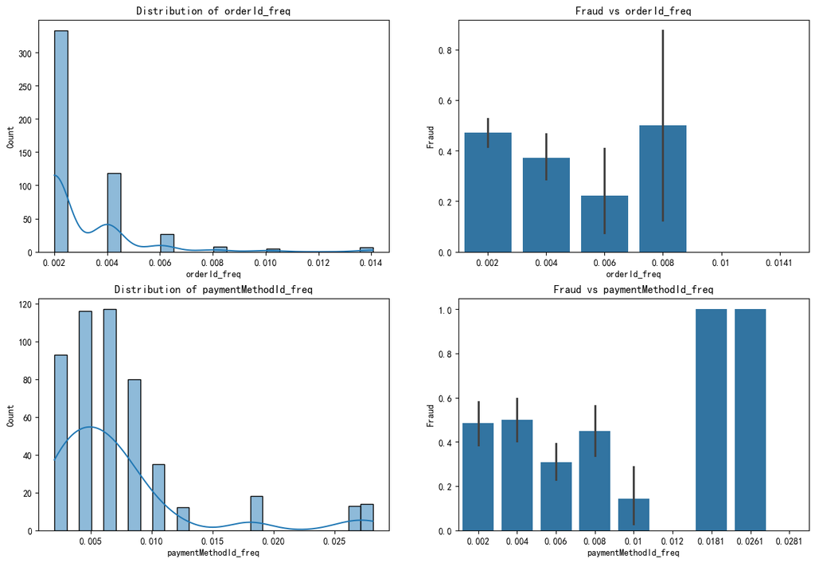

```python
countplot_distribution(train, ['orderId', 'paymentMethodId'], 'Fraud', num_cols=2, freq=True)
```

```python
from scipy.stats import spearmanr
from sklearn.feature_selection import mutual_info_classif

freq(train, 'orderId', 'orderId_freq')
print(f'orderId_freq和Fraud的相关性:')
corr, p = spearmanr(train['orderId_freq'], train['Fraud'])
print(f'Spearman correlation = {corr:.3f}, p-value = {p:.3f}')
mi = mutual_info_classif(train[['orderId_freq']], train['Fraud'], random_state=42)
print(f"Mutual Information = {mi[0]:.4f}", end='\n\n')
train.drop('orderId_freq', axis=1, inplace=True)

freq(train, 'paymentMethodId', 'paymentMethodId_freq')
print(f'paymentMethodId_freq和Fraud的相关性:')
corr, p = spearmanr(train['paymentMethodId_freq'], train['Fraud'])
print(f'Spearman correlation = {corr:.3f}, p-value = {p:.3f}')
mi = mutual_info_classif(train[['paymentMethodId_freq']], train['Fraud'], random_state=42)
print(f"Mutual Information = {mi[0]:.4f}")
train.drop('paymentMethodId_freq', axis=1, inplace=True)
```

```
orderId_freq和Fraud的相关性:
Spearman correlation = -0.151, p-value = 0.001
Mutual Information = 0.0246

paymentMethodId_freq和Fraud的相关性:
Spearman correlation = -0.065, p-value = 0.150
Mutual Information = 0.1059
```

考虑到 `count` 变量受样本量影响，因此使用出现 `freq`（count/n）来保证该变量的可移植性。  
两个变量的 Spearman 相关性整体较弱，其中 `orderId_freq` 与欺诈标签之间存在显著的负相关关系（ρ = -0.151，p = 0.001），说明用户下单次数越多，欺诈概率越低；而 `paymentMethodId_freq` 与欺诈标签的相关性较弱且不显著（ρ = -0.065，p = 0.150），表明支付方式数量与欺诈率之间不存在明显的单调关系。  
从互信息指标来看，`orderId_freq` 的互信息为 0.0246，而 `paymentMethodId_freq` 的互信息为 0.1059，后者更高，说明支付方式数量与欺诈行为之间存在一定的非线性关联，其预测潜力可能高于订单次数特征。综合来看，这两个特征虽然线性相关性较弱，但可能在不同区间呈现分段或非线性模式。考虑假如这两个特征，同时为解决右偏分布问题，对它们进行 `log1p` 处理。

```python
dic = []
dic.append({'name': 'ds'})
```

```python
# 定义一个类，用于对指定列进行频率编码
class freqEncoder(BaseEstimator, TransformerMixin):
    def __init__(self, cols, keep_cols=False, log=False):
        self.cols = cols
        self.freq_dict = {}
        self.keep_cols = keep_cols
        self.log = log

    def fit(self, X, y=None):
        for col in self.cols:
            self.freq_dict[col] = X[col].value_counts(normalize=True, dropna=False).to_dict()
        return self

    def transform(self, X):
        X_ = X.copy()
        for col in self.cols:
            X_[f'{col}_freq'] = X_[col].map(self.freq_dict[col]).fillna(0)
            if self.log == True:
                X_[f'{col}_freq'] = np.log1p(X_[f'{col}_freq'])
        if self.keep_cols == False:
            X_.drop(self.cols, axis=1, inplace=True)
        return X_

    def get_feature_names_out(self, input_features=None):
        if input_features is None:
            input_features = []
        new = [f"{c}_freq" for c in self.cols]
        return np.array(new)
```

检查其余数值以及分类特征的分布情况，并检查其对目标变量的影响：

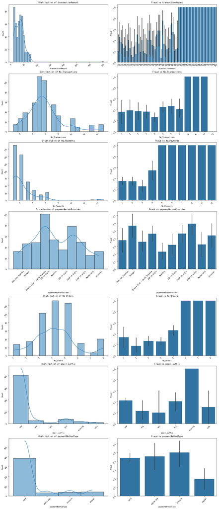

```python
cols = ['transactionAmount','No_Transactions','No_Payments', 'paymentMethodProvider', 'No_Orders', 'email_suffix', 'paymentMethodType']
plot_distribution(train, cols, 'Fraud', num_cols=len(cols))
```

```python
def transactionAmount_log(df):
    df['transactionAmount_log'] = np.log1p(df['transactionAmount'])
    return df

def transactionAmount_cut(df):
    df['transactionAmount'] = pd.cut(
        df['transactionAmount'],
        bins=[0,20,50,float('inf')],
        labels=['Low','Medium','High']
    )
    return df
```

```python
def No_Transactions_cut(df):
    df['No_Transactions'] = pd.cut(
        df['No_Transactions'],
        bins=[0,3,8,float('inf')],
        labels=['1-3','4-8','9+']
    )
    return df
```

```python
def No_Payments_cut(df):
    df['No_Payments'] = pd.cut(
        df['No_Payments'],
        bins=[0,2,4,float('inf')],
        labels=['1-2','3-4','5+']
    )
    return df
```

```python
def No_Orders_cut(df):
    df['No_Orders'] = pd.cut(
        df['No_Orders'],
        bins=[0,2,5,float('inf')],
        labels=['1-2','3-5','6+']
    )
    return df
```

定义变量 `is_fulfilled`，当 `orderState` 的取值为 'fulfilled' 时赋值为 True，否则为 False。

```python
def is_fulfilled(df):
    df['is_fulfilled'] = (df['orderState'] == 'fulfilled')
    df.drop('orderState', axis=1, inplace=True)
    return df
```

数据预处理函数:

```python
def prepossess(df):
    df = df.copy()
    transactionAmount_log(df)
    transactionAmount_cut(df)
    No_Transactions_cut(df)
    No_Payments_cut(df)
    No_Orders_cut(df)
    is_fulfilled(df)
    return df
```

```python
train = prepossess(train)
test = prepossess(test)
```

```python
train
```

|  | orderId | paymentMethodId | paymentMethodRegistrationFailure | paymentMethodType | paymentMethodProvider | transactionAmount | transactionFailed | No_Transactions | No_Orders | No_Payments | Fraud | addr_is_military | ip_is_private | email_suffix | email_is_free | transactionAmount_log | is_fulfilled |
| --- | --- | --- | --- | --- | --- | --- | --- | --- | --- | --- | --- | --- | --- | --- | --- | --- | --- |
| 209 | 809d5o | f3l73qqm9 | 0 | card | American Express | Medium | 0 | 4-8 | 3-5 | 5+ | True | 0 | 0 | com | 0 | 3.850148 | True |
| 312 | zwxx7h | ktxquppwn | 0 | card | Voyager | Low | 0 | 4-8 | 3-5 | 1-2 | False | 0 | 0 | com | 1 | 2.772589 | False |
| 513 | 1luqt9 | 4nf29mjz1 | 0 | card | Diners Club / Carte Blanche | Medium | 0 | 9+ | 3-5 | 1-2 | False | 1 | 0 | com | 1 | 3.713572 | True |
| 462 | wyeexx | 9i0e5d5ex | 0 | card | JCB 16 digit | Medium | 0 | 4-8 | 3-5 | 1-2 | False | 0 | 0 | com | 1 | 3.912023 | True |
| 574 | die097 | 8ty2ztfnr | 0 | apple pay | Maestro | Medium | 0 | 4-8 | 3-5 | 1-2 | False | 0 | 0 | com | 1 | 3.806662 | True |
| ... | ... | ... | ... | ... | ... | ... | ... | ... | ... | ... | ... | ... | ... | ... | ... | ... | ... |
| 71 | iyl91j | 6n2psn50k | 0 | card | Voyager | Low | 0 | 4-8 | 3-5 | 1-2 | False | 0 | 0 | com | 0 | 2.564949 | True |
| 106 | kv9he2 | jud25x4mo | 0 | card | Maestro | Medium | 0 | 4-8 | 3-5 | 1-2 | False | 1 | 0 | com | 0 | 3.931826 | True |
| 270 | 87w5rm | 74rqcnogo | 0 | card | Voyager | Medium | 1 | 4-8 | 3-5 | 1-2 | False | 0 | 1 | com | 1 | 3.555348 | True |
| 435 | 1pxm7n | jwnmuewma | 0 | card | VISA 16 digit | High | 0 | 4-8 | 3-5 | 5+ | True | 1 | 0 | com | 0 | 4.127134 | True |
| 102 | 8iq07j | wlywsk5au | 0 | card | VISA 16 digit | Medium | 0 | 4-8 | 3-5 | 1-2 | False | 0 | 0 | biz | 0 | 3.688879 | False |

498 rows × 17 columns

其中 `orderId` 和 `paymentMethodId` 需要进行频率编码。 `paymentMethodType`，`paymentMethodProvider`，`transactionAmount`，`No_Transactions`，`No_Orders`，`No_Payments`和`email_suffix`需要进行独热编码。

```python
X_train = train.drop(['Fraud'], axis=1)
y_train = train['Fraud']
X_test = test.drop(['Fraud'], axis=1)
y_test = test['Fraud']
```

通过 **RandomizedSearchCV** 做**嵌套交叉验证**（外3层内3层）来选择最佳模型：  
先定义一个**折内找阈值的函数**，**根据给定阈值对概率预测打分并生成报告的函数**以及**随机搜索嵌套交叉检验函数**

```python
# 折内找阈值，返回最佳阈值
def find_threshold(X_train, y_train, clf, k=5, tp=None, tr=None, priority='f1',random_state=42, positive_label=1):
    from sklearn.model_selection import StratifiedKFold, cross_val_predict
    from sklearn.metrics import precision_recall_curve, accuracy_score

    # 计算y_proba
    classes_sorted = list(np.unique(y_train))
    pos_idx = classes_sorted.index(positive_label)
    kf = StratifiedKFold(n_splits=k, shuffle=True, random_state=random_state)
    y_proba = cross_val_predict(clf, X_train, y_train, cv=kf, method='predict_proba')[:, pos_idx]

    # 计算最佳阈值
    if priority =='accuracy':
        y_proba_unique = np.sort(np.unique(y_proba))
        mid_points = (y_proba_unique[:-1]+y_proba_unique[1:])/2
        candidates = np.r_[0.0, mid_points, 1.0]
        threshold_best = 0
        acc_best = -1
        for thre in candidates:
            y_pred = (y_proba >= thre).astype(int)
            acc = accuracy_score(y_train, y_pred)
            if acc > acc_best:
                acc_best, threshold_best = acc, thre
        print(f"Best threshold: {threshold_best:}")
        print(f"Accuracy at best threshold: {accuracy_score(y_train, (y_proba >= threshold_best).astype(int)):}")
        return threshold_best

    else:
        # 计算precision-recall曲线
        precision, recall, threshold = precision_recall_curve(y_train, y_proba)
        precision, recall = precision[:-1], recall[:-1]
        # 判断priority
        if priority == 'f1':
            target_series = 2 * precision * recall / (precision + recall + 1e-12)
        elif priority == 'precision':
            target_series = precision
        elif priority =='recall':
            target_series = recall
        elif priority == 'closest':
            if (tp is not None) and (tr is not None):
                target_series = -((precision - tp)**2 + (recall - tr)**2)
            elif tp is not None:
                target_series = -(precision - tp)**2
            elif tr is not None:
                target_series = -(recall - tr)**2
            else:
                print('No target value is given. Use default value 1 for target precision and 1 for target recall.')
                target_series = -((precision - 1)**2 + (recall - 1)**2)
        # elif priority == 'accuracy':
        #     target_series = (y_train == y_proba.round()).astype(int)
        else:
            raise ValueError("priority only support 'f1'|'recall'|'precision'|'closest'。")



        # 如果tp和tr都不为None
        if (tr is not None) and (tp is not None):
            mask = (recall >= tr) & (precision >= tp)
            if mask.any():
                global_index = np.arange(len(threshold))[mask]
                threshold_best_index = global_index[np.argmax(target_series[mask])]
                threshold_best = threshold[threshold_best_index]
                print(f"Best threshold: {threshold_best}")
                print(f"Precision at best threshold: {precision[threshold_best_index]}")
                print(f"Recall at best threshold: {recall[threshold_best_index]}")
                return threshold_best
            else:
                print(f'No any threshold make precision above {tp} and recall above {tr}')
                return None

        # 如果tr不为None
        elif tr is not None:
            mask = recall >= tr
            if mask.any():
                idx = np.argmax(target_series[mask])
                threshold_best = threshold[mask][idx]
                print(f"Best threshold: {threshold_best}")
                print(f"Precision at best threshold: {precision[threshold_best_index]}")
                print(f"Recall at best threshold: {recall[threshold_best_index]}")
                return threshold_best
            else:
                print(f'No any threshold make recall above {tr}')
                return None

        # 如果tp不为None
        elif tp is not None:
            mask = precision >= tp
            if mask.any():
                idx = np.argmax(target_series[mask])
                threshold_best = threshold[mask][idx]
                print(f"Best threshold: {threshold_best}")
                print(f"Precision at best threshold: {precision[mask][idx]}")
                print(f"Recall at best threshold: {recall[mask][idx]}")
                return threshold_best
            else:
                print(f'No any threshold make precision above {tp}')
                return None

        # 如果tp和tr都为None
        elif (tp is None) and (tr is None):
            threshold_best = threshold[np.argmax(target_series)]
            print(f"Best threshold: {threshold_best}")
            print(f"Precision at best threshold: {precision[np.argmax(target_series)]}")
            print(f"Recall at best threshold: {recall[np.argmax(target_series)]}")
            return threshold_best
```

```python
# 根据给定阈值对概率预测打分并生成报告，返回 y_pred。
def evaluate_threshold(y_test, y_proba, threshold=0.5, show_matrix=True):
    from sklearn.metrics import (
    accuracy_score, precision_score, recall_score,
    f1_score, roc_auc_score, average_precision_score,
    confusion_matrix, classification_report
    )

     # 根据阈值转为 0/1
    y_pred = (y_proba >= threshold).astype(int)

    # 计算主要指标
    metrics = {
        "Threshold": threshold,
        "Accuracy": accuracy_score(y_test, y_pred)*100,
        "Precision": precision_score(y_test, y_pred, zero_division=0)*100,
        "Recall": recall_score(y_test, y_pred, zero_division=0)*100,
        "F1": f1_score(y_test, y_pred, zero_division=0)*100,
        "ROC-AUC": roc_auc_score(y_test, y_proba)*100,
        "PR-AUC": average_precision_score(y_test, y_proba)*100
    }

    print("\n📊 Model Evaluation at Threshold =", round(threshold, 3))
    display(pd.DataFrame(metrics, index=["Score"]).T)

    if show_matrix:
        print("\nConfusion Matrix:")
        print(confusion_matrix(y_test, y_pred))
        print("\nClassification Report:")
        print(classification_report(y_test, y_pred, digits=4))

    return y_pred
```

```python
# 用RandomizedSearchCV寻找最佳模型
def find_best_model(X_train, y_train, outer_kf=5, inner_kf=3, n_repeats=5, random_state=42,onehot_cols=None, freq_cols=None, fit=None):
    from scipy.stats import randint, loguniform, uniform
    from sklearn.model_selection import RepeatedStratifiedKFold, StratifiedKFold, cross_validate, RandomizedSearchCV
    from sklearn.pipeline import Pipeline
    from sklearn.preprocessing import StandardScaler, OneHotEncoder
    from sklearn.linear_model import LogisticRegression
    from sklearn.tree import DecisionTreeClassifier
    from sklearn.ensemble import RandomForestClassifier, GradientBoostingClassifier, HistGradientBoostingClassifier
    import category_encoders as ce
    from xgboost import XGBClassifier
    from lightgbm import LGBMClassifier
    from catboost import CatBoostClassifier

    # Repeated Stratified K-Fold
    outer_kf = RepeatedStratifiedKFold(n_splits=outer_kf, n_repeats=n_repeats, random_state=random_state)
    inner_kf = StratifiedKFold(n_splits=inner_kf, shuffle=True, random_state=random_state)

    # Class weight adjustment
    y_ratio = (y_train == 0).sum() / (y_train == 1).sum()
    if y_ratio > 3/2 or y_ratio < 2/3:
        class_weight = 'balanced'
        scale_pos_weight = y_ratio
        class_weights = {0:1, 1:y_ratio}
    else:
        class_weight = None
        scale_pos_weight = None
        class_weights = None


    preprocessor  = []
    # freqEncoder
    if freq_cols is not None and len(freq_cols)>0:
        fe = freqEncoder(
            cols=freq_cols,
            log=True
        )
        preprocessor.append(('fe', fe, freq_cols))

    # OnehotEncoder
    if onehot_cols is not None and len(onehot_cols)>0:
        ohe =  OneHotEncoder(
           handle_unknown='ignore'
        )
        preprocessor.append(('ohe', ohe, onehot_cols))

    pre = ColumnTransformer(
        preprocessor,
        remainder='passthrough'
    )


    random_params = {
        'Logistic Regression': {
            'clf__max_iter': randint(500, 2000),
            'clf__penalty': ['l1', 'l2'],
            'clf__C': loguniform(1e-4, 1e4),
            'clf__solver': ['liblinear', 'saga'],
        },
        'Decision Tree': {
            'clf__min_samples_leaf': randint(1, 10),
            'clf__min_samples_split': randint(2, 10),
            'clf__max_depth': randint(2, 10),
            'clf__criterion': ['gini', 'log_loss'],
            'clf__max_features': ['sqrt', 'log2', None]
        },
        'Random Forest': {
            'clf__n_estimators': randint(100, 800),
            'clf__min_samples_leaf': randint(1,10),
            'clf__min_samples_split': randint(2,10),
            'clf__max_depth': randint(2, 10),
            'clf__max_features': ['sqrt', 'log2']
        },
        'GBM': {
            'clf__n_estimators': randint(100, 1000),
            'clf__learning_rate': loguniform(1e-2, 3e-1),
            'clf__min_samples_split': randint(2, 10),
            'clf__min_samples_leaf': randint(1, 10),
            'clf__subsample': uniform(0.5, 0.5),
            'clf__max_depth': randint(2, 10),
            'clf__max_features': ['sqrt','log2', None]
        },
        'XGBoost': {
            'clf__n_estimators': randint(100, 1200),
            'clf__learning_rate': loguniform(1e-2, 3e-1),
            'clf__max_depth': randint(2, 10),
            'clf__subsample': uniform(0.5, 0.5),
            'clf__colsample_bytree': uniform(0.5, 0.5),
            'clf__min_child_weight': loguniform(1e-2, 1e1),
            'clf__gamma': loguniform(1e-8, 1e0),
            'clf__reg_alpha': loguniform(1e-8, 1e-1),
            'clf__reg_lambda': loguniform(1e-3, 1e1)
        },
        'LightGBM': {
            'clf__n_estimators': randint(100, 1200),
            'clf__learning_rate': loguniform(1e-2, 3e-1),
            'clf__num_leaves': randint(15, 255),
            'clf__min_child_samples': randint(1, 50),
            'clf__min_child_weight': loguniform(1e-3, 1e2),
            'clf__feature_fraction': uniform(0.5, 0.5),
            'clf__bagging_fraction': uniform(0.5, 0.5),
            'clf__bagging_freq': randint(1, 10),
            'clf__max_depth': randint(-1,12),
            'clf__lambda_l1': loguniform(1e-4, 10),
            'clf__lambda_l2': loguniform(1e-4, 10)
        },
        'CatBoost': {
            'clf__iterations': randint(200, 1200),
            'clf__learning_rate': loguniform(1e-2, 3e-1),
            'clf__rsm': uniform(0.5, 0.5),
            'clf__depth': randint(2,10),
            'clf__l2_leaf_reg': loguniform(1e-2, 1e2)
        },
        'HistBoost': {
            'clf__max_iter': randint(100, 800),
            'clf__learning_rate': loguniform(1e-2, 3e-1),
            'clf__max_depth': randint(2, 12),
            'clf__min_samples_leaf': randint(2, 100),
            'clf__max_leaf_nodes': randint(15, 255),
            'clf__l2_regularization': loguniform(1e-6, 1e1),
            'clf__max_bins': randint(128, 255)
        }
    }

    # Define models
    models = {
        'Logistic Regression': Pipeline(
            [('pre', pre)] +
            [('scaler', StandardScaler())]+
            [('clf', LogisticRegression(class_weight=class_weight,
                                      random_state=random_state))]
            ),
        'Decision Tree': Pipeline(
            [('pre', pre)] +
            [('clf', DecisionTreeClassifier(class_weight=class_weight,
                                           random_state=random_state))]
            ),
        'Random Forest': Pipeline(
            [('pre', pre)] +
            [('clf', RandomForestClassifier(n_jobs=1,
                                           class_weight=class_weight,
                                           random_state=random_state))]
            ),
        'GBM': Pipeline(
            [('pre', pre)] +
            [('clf', GradientBoostingClassifier(random_state=random_state))]
            ),
        'XGBoost': Pipeline(
            [('pre', pre)] +
            [('clf', XGBClassifier(n_jobs=1,
                                  scale_pos_weight=scale_pos_weight,
                                  random_state=random_state))]
            ),
        'LightGBM': Pipeline(
            [('pre', pre)] +
            [('clf', LGBMClassifier(n_jobs=1,
                                   class_weight=class_weight,
                                   verbose=-1,
                                   random_state=random_state))]
            ),
        'CatBoost': Pipeline(
            [('pre', pre)] +
            [('clf', CatBoostClassifier(thread_count=1,
                                       class_weights=class_weights,
                                       verbose=0,
                                       allow_writing_files=False,
                                       random_state=random_state))]
            ),
        'HistBoost': Pipeline(
            [('pre', pre)] +
            [('clf', HistGradientBoostingClassifier(class_weight=class_weight,
                                                   random_state=random_state))]
            )
    }

    # Fit selected model
    if fit is not None:
        if fit not in models:
            raise ValueError(f"Only support 'Logistic Regression', 'Decision Tree', 'Random Forest', 'GBM', 'XGBoost', 'LightGBM', 'CatBoost', 'HistBoost'.")
        else:
            search_random = RandomizedSearchCV(
                models[fit],
                param_distributions=random_params[fit],
                cv=inner_kf,
                scoring='average_precision',
                random_state=random_state,
                n_iter=100,
                n_jobs=1,
                verbose=0,
                error_score='raise',
                refit=True
            )
            search_random.fit(X_train, y_train)
            return search_random

    # Cross-validation
    cv_results = []
    for name, model in models.items():
        # Random Search
        search_random = RandomizedSearchCV(
            model,
            param_distributions=random_params[name],
            cv=inner_kf,
            scoring='average_precision',
            random_state=random_state,
            n_iter=40,
            n_jobs=1,
            verbose=0,
            error_score='raise',
            refit=True
        )



        nested_scores = cross_validate(search_random,
                                           X_train, y_train,
                                           cv=outer_kf,
                                           scoring=['accuracy', 'f1', 'roc_auc', 'average_precision'],
                                           n_jobs=-1,
                                           verbose=0
                                           )

        cv_results.append({'Model': name,
                           'PR': np.mean(nested_scores['test_average_precision']),
                            'PR STD': np.std(nested_scores['test_average_precision']),
                            'AUC': np.mean(nested_scores['test_roc_auc']),
                            'AUC STD': np.std(nested_scores['test_roc_auc']),
                            'F1': np.mean(nested_scores['test_f1']),
                            'F1 STD': np.std(nested_scores['test_f1']),
                            'Accuracy': np.mean(nested_scores['test_accuracy']),
                            'Accuracy STD': np.std(nested_scores['test_accuracy'])
                           })

    model_df = pd.DataFrame(cv_results).sort_values('PR', ascending=False).reset_index(drop=True)

    model_df["PR"] = model_df.apply(lambda x: f"{x['PR']*100:.3f} ± {x['PR STD']*100:.3f}", axis=1)
    model_df["AUC"] = model_df.apply(lambda x: f"{x['AUC']*100:.3f} ± {x['AUC STD']*100:.3f}", axis=1)
    model_df["F1"] = model_df.apply(lambda x: f"{x['F1']*100:.3f} ± {x['F1 STD']*100:.3f}", axis=1)
    model_df["Accuracy"] = model_df.apply(lambda x: f"{x['Accuracy']*100:.3f} ± {x['Accuracy STD']*100:.3f}", axis=1)


    return model_df[['Model','PR','AUC','F1','Accuracy']]
```

```python
freq_cols = [
    'orderId',
    'paymentMethodId'
]
onehot_cols = [
    'paymentMethodType',
    'paymentMethodProvider',
    'transactionAmount',
    'No_Transactions',
    'No_Orders',
    'No_Payments',
    'email_suffix'
]
```

```python
find_best_model(
    X_train,
    y_train,
    freq_cols=freq_cols,
    onehot_cols=onehot_cols,
    outer_kf=3,
    inner_kf=3,
    n_repeats=1
)
```

|  | Model | PR | AUC | F1 | Accuracy |
| --- | --- | --- | --- | --- | --- |
| 0 | GBM | 93.882 ± 2.086 | 93.900 ± 1.995 | 84.475 ± 4.578 | 87.550 ± 3.490 |
| 1 | CatBoost | 93.195 ± 2.716 | 93.021 ± 2.699 | 83.377 ± 3.898 | 86.948 ± 2.882 |
| 2 | Random Forest | 92.701 ± 2.090 | 93.050 ± 2.236 | 75.563 ± 3.852 | 83.333 ± 2.218 |
| 3 | XGBoost | 92.289 ± 2.302 | 92.619 ± 2.073 | 81.765 ± 3.866 | 85.944 ± 2.709 |
| 4 | HistBoost | 90.956 ± 2.088 | 91.495 ± 2.015 | 78.288 ± 2.096 | 82.932 ± 1.862 |
| 5 | Logistic Regression | 89.526 ± 0.925 | 89.260 ± 0.648 | 76.666 ± 0.687 | 80.924 ± 1.727 |
| 6 | LightGBM | 89.454 ± 2.177 | 89.694 ± 1.724 | 79.104 ± 1.062 | 83.133 ± 0.852 |
| 7 | Decision Tree | 80.871 ± 0.736 | 84.937 ± 0.659 | 74.538 ± 1.607 | 81.526 ± 1.024 |

重点关注PR值。前几名表现都不错，其中 GBM 在所有指标上都领先或并列第一，说明它的特征工程与参数选择非常成功。本次将只用 GBM 进行训练。  
下面重新用随机搜索对整个训练集 fit GBM 模型：

```python
best_model = find_best_model(
    X_train,
    y_train,
    freq_cols=freq_cols,
    onehot_cols=onehot_cols,
    outer_kf=3,
    inner_kf=3,
    n_repeats=1,
    fit='GBM'
)
```

```python
best_model.best_estimator_
```

```
Pipeline(steps=[('pre',
                 ColumnTransformer(remainder='passthrough',
                                   transformers=[('fe',
                                                  freqEncoder(cols=['orderId',
                                                                    'paymentMethodId'],
                                                              log=True),
                                                  ['orderId',
                                                   'paymentMethodId']),
                                                 ('ohe',
                                                  OneHotEncoder(handle_unknown='ignore'),
                                                  ['paymentMethodType',
                                                   'paymentMethodProvider',
                                                   'transactionAmount',
                                                   'No_Transactions',
                                                   'No_Orders', 'No_Payments',
                                                   'email_suffix'])])),
                ('clf',
                 GradientBoostingClassifier(learning_rate=np.float64(0.06997123840203158),
                                            max_depth=9, max_features='sqrt',
                                            min_samples_split=5,
                                            n_estimators=319, random_state=42,
                                            subsample=np.float64(0.7349722569954715)))])
```

在小范围内再次进行第二次随机搜索：

```python
pipe = clone(best_model.best_estimator_)
best_params = best_model.best_params_
```

```python
# 局部随机再采样
params = {
    'clf__learning_rate': uniform(
        best_params['clf__learning_rate']*0.8,
        best_params['clf__learning_rate']*0.4
    ),
    'clf__max_depth': randint(
        max(2, best_params['clf__max_depth']-2),
        best_params['clf__max_depth']+3
    ),
    'clf__max_features': ['sqrt','log2', None],
    'clf__min_samples_leaf': randint(
        max(1, best_params['clf__min_samples_leaf']-2),
        best_params['clf__min_samples_leaf']+3
    ),
    'clf__min_samples_split': randint(
        max(2, best_params['clf__min_samples_split']-2),
        best_params['clf__min_samples_split']+3
    ),
    'clf__n_estimators': randint(
        max(50, best_params['clf__n_estimators']-100),
        best_params['clf__n_estimators']+100
    ),
    'clf__subsample': uniform(
        loc:=max(0.5, best_params['clf__subsample']*0.8),
        scale=min(1.0-loc, best_params['clf__subsample']*0.4)
    )
}

kf = RepeatedStratifiedKFold(n_splits=5, n_repeats=3, random_state=42)
random_search_final = RandomizedSearchCV(estimator=pipe,
                                   param_distributions=params,
                                   n_iter=80,
                                   cv=kf,
                                   scoring='average_precision',
                                   random_state=42,
                                   verbose=1,
                                   n_jobs=-1,
                                   refit=True
                                   )

random_search_final.fit(X_train, y_train)
```

```
Fitting 15 folds for each of 80 candidates, totalling 1200 fits
```

```
RandomizedSearchCV(cv=RepeatedStratifiedKFold(n_repeats=3, n_splits=5, random_state=42),
                   estimator=Pipeline(steps=[('pre',
                                              ColumnTransformer(remainder='passthrough',
                                                                transformers=[('fe',
                                                                               freqEncoder(cols=['orderId',
                                                                                                 'paymentMethodId'],
                                                                                           log=True),
                                                                               ['orderId',
                                                                                'paymentMethodId']),
                                                                              ('ohe',
                                                                               OneHotEncoder(handle_unknown='ignore'),
                                                                               ['paymentMethodType',
                                                                                'paymentMethod...
                                        'clf__min_samples_split': <scipy.stats._distn_infrastructure.rv_discrete_frozen object at 0x000002174E439E10>,
                                        'clf__n_estimators': <scipy.stats._distn_infrastructure.rv_discrete_frozen object at 0x000002174E438BB0>,
                                        'clf__subsample': <scipy.stats._distn_infrastructure.rv_continuous_frozen object at 0x000002174E43B970>},
                   random_state=42, scoring='average_precision', verbose=1)
```

```python
pipe_final = random_search_final.best_estimator_
# find_threshold是之前定义过的折内找阈值函数
threshold = find_threshold(X_train, y_train, pipe_final, tp=0.9, priority='recall')
```

```
Best threshold: 0.38157970137351677
Precision at best threshold: 0.9030612244897959
Recall at best threshold: 0.8388625592417062
```

```python
y_test_proba = pipe_final.predict_proba(X_test)[:,1]
# evaluate_threshold是之前定义过的打分函数
y_test_pred = evaluate_threshold(y_test, y_test_proba, threshold=threshold)
```

```
📊 Model Evaluation at Threshold = 0.382
```

|  | Score |
| --- | --- |
| Threshold | 0.381580 |
| Accuracy | 90.400000 |
| Precision | 86.956522 |
| Recall | 86.956522 |
| F1 | 86.956522 |
| ROC-AUC | 96.257567 |
| PR-AUC | 95.360926 |

```
Confusion Matrix:
[[73  6]
 [ 6 40]]

Classification Report:
              precision    recall  f1-score   support

       False     0.9241    0.9241    0.9241        79
        True     0.8696    0.8696    0.8696        46

    accuracy                         0.9040       125
   macro avg     0.8968    0.8968    0.8968       125
weighted avg     0.9040    0.9040    0.9040       125
```

**结论：**  
本次模型最终选择了 Gradient Boosting（GBM）作为主模型。经过嵌套交叉验证与验证集测试，模型在各项指标上表现稳定且优秀：验证集上的 PR-AUC 为 95.36%、ROC-AUC 为 96.26%、F1 为 86.96%、准确率约 90.4%。模型在验证集上的泛化表现完全符合甚至略超嵌套交叉验证的期望（PR≈93.9 → 95.4），表明最终模型泛化能力强，没有明显过拟合。模型在正负样本上预测均衡，既能有效识别出大部分正样本（召回高），又保持较低误报率（精度高）。总体来看，该模型在泛化能力与稳定性方面表现理想，无需再进行模型集成或更复杂的调优。

**附加：** 尝试用 Optuna 方法调参

```python
def Objective(trial):
    params = {
        'clf__learning_rate': trial.suggest_float(
            'clf__learning_rate',
            max(1e-4, best_params['clf__learning_rate']*0.8),
            min(1.0, best_params['clf__learning_rate']*1.2),
            log=True
        ),
        'clf__max_depth': trial.suggest_int(
            'clf__max_depth',
            max(2, best_params['clf__max_depth']-2),
            best_params['clf__max_depth']+3
        ),
        'clf__max_features': trial.suggest_categorical(
            'clf__max_features',
            ['sqrt','log2', None]
        ),
        'clf__min_samples_leaf': trial.suggest_int(
            'clf__min_samples_leaf',
            max(1, best_params['clf__min_samples_leaf']-2),
            best_params['clf__min_samples_leaf']+3
        ),
        'clf__min_samples_split': trial.suggest_int(
            'clf__min_samples_split',
            max(2, best_params['clf__min_samples_split']-2),
            best_params['clf__min_samples_split']+3
        ),
        'clf__n_estimators': trial.suggest_int(
            'clf__n_estimators',
            max(50, best_params['clf__n_estimators']-100),
            best_params['clf__n_estimators']+100
        ),
        'clf__subsample': trial.suggest_float(
            'clf__subsample',
            max(0.5, best_params['clf__subsample']*0.8),
            min(1.0, best_params['clf__subsample']*1.2)
        )
    }

    pipe_opt = clone(pipe).set_params(**params)
    kf = StratifiedKFold(n_splits=5, shuffle=True, random_state=42)

    pr = cross_val_score(pipe_opt, X_train, y_train, cv=kf, scoring='average_precision', n_jobs=1)

    return np.mean(pr)
```

```python
sampler = optuna.samplers.TPESampler(seed=42)
study = optuna.create_study(direction='maximize', sampler=sampler)
optuna.logging.set_verbosity(optuna.logging.WARNING)
study.optimize(
    Objective,
    n_trials=60,
    n_jobs=-1
)
study.best_params
```

```
{'clf__learning_rate': 0.058645610099511386,
 'clf__max_depth': 11,
 'clf__max_features': 'log2',
 'clf__min_samples_leaf': 1,
 'clf__min_samples_split': 5,
 'clf__n_estimators': 416,
 'clf__subsample': 0.821428279757141}
```

```python
opt_model = clone(pipe).set_params(**study.best_params)
opt_model.fit(X_train, y_train)
```

```
Pipeline(steps=[('pre',
                 ColumnTransformer(remainder='passthrough',
                                   transformers=[('fe',
                                                  freqEncoder(cols=['orderId',
                                                                    'paymentMethodId'],
                                                              log=True),
                                                  ['orderId',
                                                   'paymentMethodId']),
                                                 ('ohe',
                                                  OneHotEncoder(handle_unknown='ignore'),
                                                  ['paymentMethodType',
                                                   'paymentMethodProvider',
                                                   'transactionAmount',
                                                   'No_Transactions',
                                                   'No_Orders', 'No_Payments',
                                                   'email_suffix'])])),
                ('clf',
                 GradientBoostingClassifier(learning_rate=0.058645610099511386,
                                            max_depth=11, max_features='log2',
                                            min_samples_split=5,
                                            n_estimators=416, random_state=42,
                                            subsample=0.821428279757141))])
```

```python
threshold_opt = find_threshold(X_train, y_train, opt_model, tp=0.9, priority='recall')
```

```
Best threshold: 0.2693005463509206
Precision at best threshold: 0.9035532994923858
Recall at best threshold: 0.8436018957345972
```

```python
y_opt_proba = opt_model.predict_proba(X_test)[:, 1]
y_opt_pred = evaluate_threshold(y_test, y_opt_proba , threshold=threshold_opt)
```

```
📊 Model Evaluation at Threshold = 0.269
```

|  | Score |
| --- | --- |
| Threshold | 0.269301 |
| Accuracy | 87.200000 |
| Precision | 82.608696 |
| Recall | 82.608696 |
| F1 | 82.608696 |
| ROC-AUC | 95.734728 |
| PR-AUC | 94.716125 |

```
Confusion Matrix:
[[71  8]
 [ 8 38]]

Classification Report:
              precision    recall  f1-score   support

       False     0.8987    0.8987    0.8987        79
        True     0.8261    0.8261    0.8261        46

    accuracy                         0.8720       125
   macro avg     0.8624    0.8624    0.8624       125
weighted avg     0.8720    0.8720    0.8720       125
```